# Movies Dashboard

Elkobtan

2024-05-18

```r
library(blorr)
library(skimr)
library(shiny)
library(ResourceSelection)
library(psych)
library(plotly)
library(caret)
library(corrplot)
library(DataExplorer)
library(dplyr)
library(fBasics)
library(flexdashboard)
library(GGally)
library(ggfortify)
library(ggplot2)
library(janitor)
library(MASS)
library(knitr)
library(mice)
library(naniar)
library(olsrr)
library(factoextra)
library(tidyr)
```

```r
movies <- read.csv("C:/Users/Lapcom Store/Desktop/Predictive Project/Movies dataa.csv")
attach(movies)
```

```r
movies |> head()
```

```
##       id          title vote_average vote_count   status release_date   revenue
## 1 150540     Inside Out        7.922      13060 Released     6/9/2015 857611174
## 2  14160             Up        7.949      16828 Released    5/28/2009 735099082
## 3     12   Finding Nemo        7.824      22987 Released    5/30/2003 940335536
## 4 354912           Coco        8.222      24238 Released   10/27/2017 800526015
## 5  10681         WALL·E        8.078      17290 Released    6/22/2008 521311860
## 6    585 Monsters, Inc.        7.835      20165 Released    11/1/2001 579707738
##   runtime adult                    backdrop_path    budget
## 1      95 FALSE /j29ekbcLpBvxnGk6LjdTc2EI5SA.jpg 175000000
## 2      96 FALSE /hGGC9gKo7CFE3fW07RA587e5kol.jpg 175000000
## 3     100 FALSE /h3uqFk7sZRJvLZDdLiFB9qwbL07.jpg  94000000
## 4     105 FALSE /askg3SMvhqEl4OL52YuvdtY40Yb.jpg 175000000
## 5      98 FALSE /fK5ssgvtI43z19FoWigdlqgpLRE.jpg 180000000
## 6      92 FALSE /vUTVUdfbsY4DePCYzxxDMXKp6v6.jpg 115000000
##                                     homepage   imdb_id original_language
```

[output cut: 48 more lines]

```r
movies$id <- 1:nrow(movies)
head(movies)
```

```
##   id          title vote_average vote_count   status release_date   revenue
## 1  1     Inside Out        7.922      13060 Released     6/9/2015 857611174
## 2  2             Up        7.949      16828 Released    5/28/2009 735099082
## 3  3   Finding Nemo        7.824      22987 Released    5/30/2003 940335536
## 4  4           Coco        8.222      24238 Released   10/27/2017 800526015
## 5  5         WALL·E        8.078      17290 Released    6/22/2008 521311860
## 6  6 Monsters, Inc.        7.835      20165 Released    11/1/2001 579707738
##   runtime adult                    backdrop_path    budget
## 1      95 FALSE /j29ekbcLpBvxnGk6LjdTc2EI5SA.jpg 175000000
## 2      96 FALSE /hGGC9gKo7CFE3fW07RA587e5kol.jpg 175000000
## 3     100 FALSE /h3uqFk7sZRJvLZDdLiFB9qwbL07.jpg  94000000
## 4     105 FALSE /askg3SMvhqEl4OL52YuvdtY40Yb.jpg 175000000
## 5      98 FALSE /fK5ssgvtI43z19FoWigdlqgpLRE.jpg 180000000
## 6      92 FALSE /vUTVUdfbsY4DePCYzxxDMXKp6v6.jpg 115000000
##                                     homepage   imdb_id original_language
```

[output cut: 48 more lines]

```r
movies[movies == ""] <- NA
```

```r
movies |> skim()
```

Data summary

| Name | movies |
| --- | --- |
| Number of rows | 21156 |
| Number of columns | 23 |
| _______________________ |  |
| Column type frequency: |  |
| character | 15 |
| logical | 1 |
| numeric | 7 |
| ________________________ |  |
| Group variables | None |

**Variable type: character**

| skim_variable | n_missing | complete_rate | min | max | empty | n_unique | whitespace |
| --- | --- | --- | --- | --- | --- | --- | --- |
| title | 0 | 1.00 | 1 | 115 | 0 | 20600 | 0 |
| status | 0 | 1.00 | 7 | 13 | 0 | 3 | 0 |
| release_date | 155 | 0.99 | 8 | 10 | 0 | 11597 | 0 |
| backdrop_path | 9442 | 0.55 | 30 | 32 | 0 | 11656 | 0 |
| homepage | 17132 | 0.19 | 15 | 145 | 0 | 3777 | 0 |
| imdb_id | 3521 | 0.83 | 9 | 10 | 0 | 17635 | 0 |
| original_language | 0 | 1.00 | 2 | 2 | 0 | 80 | 0 |
| original_title | 0 | 1.00 | 1 | 105 | 0 | 20789 | 0 |
| overview | 1550 | 0.93 | 3 | 1000 | 0 | 19500 | 0 |
| poster_path | 2954 | 0.86 | 30 | 32 | 0 | 18175 | 0 |
| tagline | 18165 | 0.14 | 3 | 252 | 0 | 2919 | 0 |
| genres | 0 | 1.00 | 9 | 86 | 0 | 2137 | 0 |
| production_companies | 5579 | 0.74 | 2 | 514 | 0 | 6736 | 0 |
| production_countries | 2976 | 0.86 | 4 | 199 | 0 | 749 | 0 |
| spoken_languages | 4048 | 0.81 | 4 | 59 | 0 | 480 | 0 |

**Variable type: logical**

| skim_variable | n_missing | complete_rate | mean | count |
| --- | --- | --- | --- | --- |
| adult | 0 | 1 | 0 | FAL: 21083, TRU: 73 |

**Variable type: numeric**

| skim_variable | n_missing | complete_rate | mean | sd | p0 | p25 | p50 | p75 | p100 | hist |
| --- | --- | --- | --- | --- | --- | --- | --- | --- | --- | --- |
| id | 0 | 1 | 10578.50 | 6107.36 | 1.0 | 5289.75 | 10578.50 | 1.586725e+04 | 2.115600e+04 | ▇▇▇▇▇ |
| vote_average | 0 | 1 | 6.38 | 1.72 | 0.5 | 5.50 | 6.45 | 7.200000e+00 | 1.000000e+01 | ▁▁▆▇▂ |
| vote_count | 0 | 1 | 20009.14 | 5732.91 | 10000.0 | 15124.75 | 20028.50 | 2.497100e+04 | 3.000000e+04 | ▇▇▇▇▇ |
| revenue | 0 | 1 | 697807166.03 | 432928710.49 | 1.0 | 317545815.25 | 699996379.00 | 1.070782e+09 | 1.450027e+09 | ▇▆▆▆▆ |
| runtime | 0 | 1 | 151.15 | 119.17 | 14.0 | 59.00 | 98.00 | 2.440000e+02 | 4.200000e+02 | ▇▃▂▂▂ |
| budget | 0 | 1 | 123588309.07 | 77483320.45 | 1.0 | 55516424.50 | 122430496.50 | 1.910968e+08 | 2.600000e+08 | ▇▇▆▆▆ |
| popularity | 0 | 1 | 3.63 | 14.99 | 0.0 | 0.60 | 0.90 | 2.160000e+00 | 1.008940e+03 | ▇▁▁▁▁ |

```r
movies <- clean_names(movies)
```

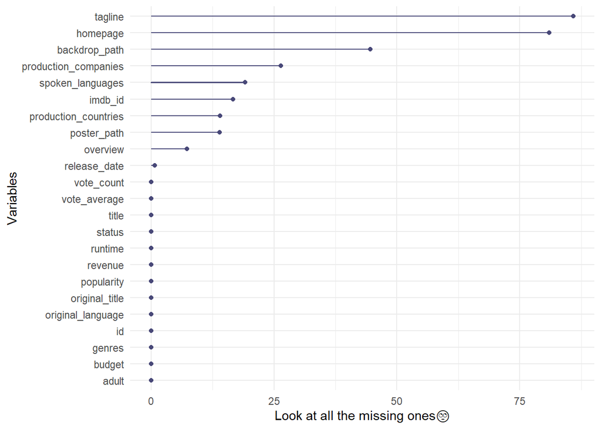

```r
gg_miss_var(movies,show_pct = TRUE) + labs(y = "Look at all the missing ones🙄")
```

```r
movies |> miss_var_summary()
```

```
## # A tibble: 23 × 3
##    variable             n_miss pct_miss
##    <chr>                 <int>    <num>
##  1 tagline               18165   85.9
##  2 homepage              17132   81.0
##  3 backdrop_path          9442   44.6
##  4 production_companies   5579   26.4
##  5 spoken_languages       4048   19.1
##  6 imdb_id                3521   16.6
##  7 production_countries   2976   14.1
##  8 poster_path            2954   14.0
##  9 overview               1550    7.33
## 10 release_date            155    0.733
## # ℹ 13 more rows
```

```r
movies <- movies[, !names(movies) %in% c("tagline", "homepage","overview","poster_path","original_language","backdrop_path","imdb_id","production_companies","original_title")]
```

```r
movies |> miss_var_summary()
```

```
## # A tibble: 14 × 3
##    variable             n_miss pct_miss
##    <chr>                 <int>    <num>
##  1 spoken_languages       4048   19.1
##  2 production_countries   2976   14.1
##  3 release_date            155    0.733
##  4 id                        0    0
##  5 title                     0    0
##  6 vote_average              0    0
##  7 vote_count                0    0
##  8 status                    0    0
##  9 revenue                   0    0
## 10 runtime                   0    0
## 11 adult                     0    0
## 12 budget                    0    0
## 13 popularity                0    0
## 14 genres                    0    0
```

```r
movies <- read.csv("C:/Users/Lapcom Store/Desktop/Predictive Project/movies.csv")
```

```r
movies |> miss_var_summary()
```

```
## # A tibble: 14 × 3
##    variable             n_miss pct_miss
##    <chr>                 <int>    <num>
##  1 id                        0        0
##  2 title                     0        0
##  3 vote_average              0        0
##  4 vote_count                0        0
##  5 status                    0        0
##  6 release_date              0        0
##  7 revenue                   0        0
##  8 runtime                   0        0
##  9 adult                     0        0
## 10 budget                    0        0
## 11 popularity                0        0
## 12 genres                    0        0
## 13 production_countries      0        0
## 14 spoken_languages          0        0
```

```r
library(lubridate)
movies$release_date <- format(mdy(movies$release_date), format = "%Y")
```

```r
movies <- movies |>
  rename(release_year = release_date )
```

```r
movies$release_year <- as.integer(movies$release_year)
```

```r
process_genres <- function(genres) {
  genre_list <- strsplit(genres, ", ")[[1]]
  if (genre_list[1] == "Animation") {
    return(genre_list[2])
  } else {
    return(genre_list[1])
  }
}
movies$genres <- sapply(movies$genres, process_genres)
```

```r
movies <- movies[, !names(movies) %in% c("process_genres")]
```

```r
str(movies)
```

```
## 'data.frame':    21156 obs. of  14 variables:
##  $ id                  : num  1 2 3 4 5 6 7 8 9 10 ...
##  $ title               : chr  "Inside Out" "Up" "Finding Nemo" "Coco" ...
##  $ vote_average        : num  7.92 7.95 7.82 8.22 8.08 ...
##  $ vote_count          : num  13060 16828 22987 24238 17290 ...
##  $ status              : chr  "Released" "Released" "Released" "Released" ...
##  $ release_year        : int  2015 2009 2003 2017 2008 2001 1995 1994 2004 2001 ...
##  $ revenue             : num  8.58e+08 7.35e+08 9.40e+08 8.01e+08 5.21e+08 ...
##  $ runtime             : num  95 96 100 105 98 92 81 89 115 90 ...
##  $ adult               : chr  "False" "False" "False" "False" ...
##  $ budget              : num  1.75e+08 1.75e+08 9.40e+07 1.75e+08 1.80e+08 1.15e+08 3.00e+07 4.50e+07 9.20e+07 6.00e+07 ...
##  $ popularity          : num  107.3 91 55.5 166.6 58.5 ...
##  $ genres              : chr  "Family" "Comedy" "Family" "Family" ...
##  $ production_countries: chr  "United States of America" "United States of America" "United States of America" "United States of America" ...
##  $ spoken_languages    : chr  "English" "English" "English" "English, Spanish" ...
```

```r
movies <- na.omit(movies[movies$release_year, ])
```

```r
numeric_data <- movies[, c("vote_average","vote_count","revenue","runtime","budget","popularity","release_year")]
numeric_data[] <- lapply(numeric_data, as.numeric)
```

```r
categorical_data <- movies[, c("title","status","genres","production_countries","spoken_languages")]
categorical_data <- data.frame(lapply(categorical_data, as.factor))
```

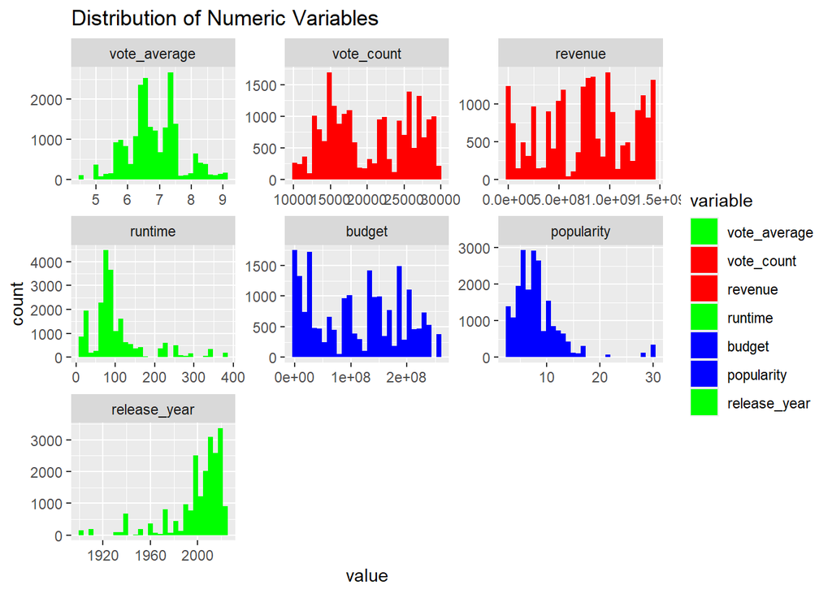

```r
numeric_data_long <- reshape2::melt(numeric_data)
colors <- c("id" = "blue",
            "vote_average" = "green",
            "vote_count" = "red",
            "revenue" = "red",
            "runtime" = "green",
            "budget" = "blue",
            "popularity" = "blue",
            "release_year" = "green")
ggplot(numeric_data_long, aes(x=value, fill=variable)) +
  geom_histogram(bins = 30) +
  facet_wrap(~variable, scales = "free") +
  scale_fill_manual(values = colors) +
  labs(title = "Distribution of Numeric Variables")
```

```r
rm(numeric_data_long)
```

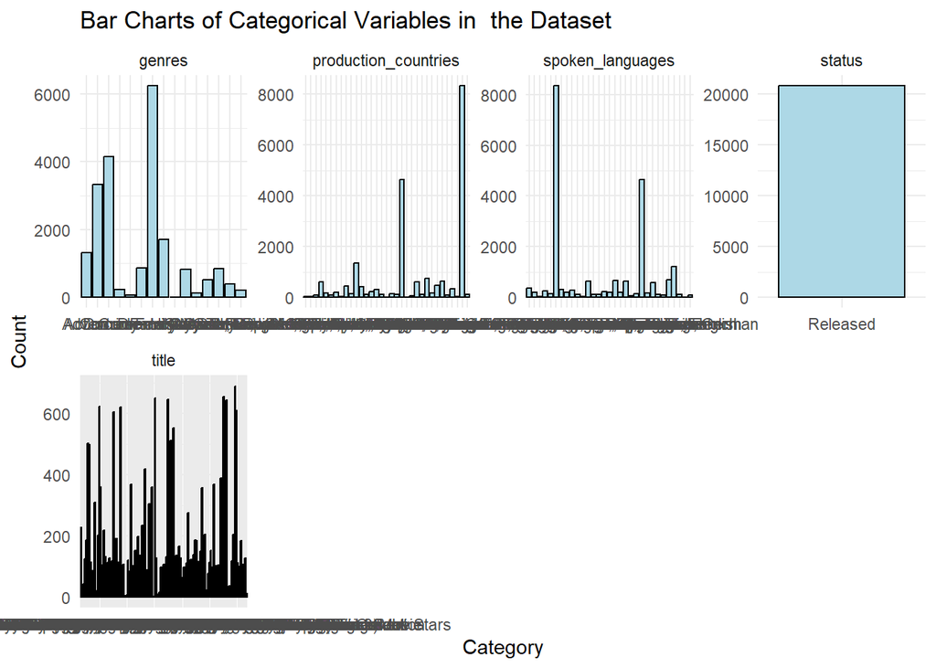

```r
categorical_data |>
  pivot_longer(cols = everything(),
               names_to = "variable",
               values_to = "value") |>
  ggplot(aes(x = value)) +
  geom_bar(color = "black", fill = "lightblue") +
  facet_wrap(~ variable, scales = "free", ncol = 4) +
  labs(title = "Bar Charts of Categorical Variables in  the Dataset",
       x = "Category",
       y = "Count") +
  theme_minimal()
```

```r
categorical_cardinality <- categorical_data %>%
  summarise_all(n_distinct) %>%
  gather(variable, cardinality) %>%
  arrange(desc(cardinality)) %>%
  knitr::kable(caption = "Cardinality of Categorical Variables")

print(categorical_cardinality)
```

```
##
##
## Table: Cardinality of Categorical Variables
##
## |variable             | cardinality|
## |:--------------------|-----------:|
## |title                |         117|
## |production_countries |          33|
## |spoken_languages     |          31|
## |genres               |          15|
## |status               |           1|
```

```r
movies <- movies[, !names(movies) %in% c("status")]
```

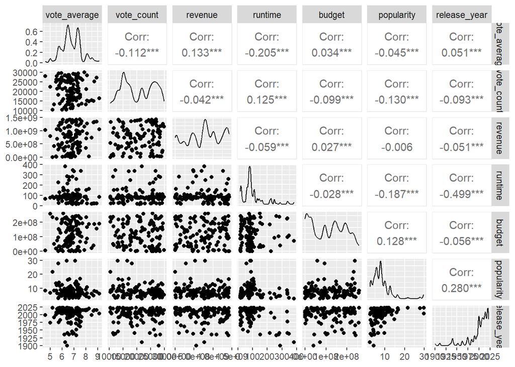

```r
ggpairs(numeric_data)
```

```r
correlation_matrix <- cor(numeric_data)

summary(correlation_matrix)
```

```
##   vote_average        vote_count          revenue             runtime
##  Min.   :-0.20509   Min.   :-0.13007   Min.   :-0.059337   Min.   :-0.49908
##  1st Qu.:-0.07839   1st Qu.:-0.10542   1st Qu.:-0.046286   1st Qu.:-0.19629
##  Median : 0.03374   Median :-0.09320   Median :-0.006494   Median :-0.05934
##  Mean   : 0.12229   Mean   : 0.09273   Mean   : 0.143078   Mean   : 0.02084
##  3rd Qu.: 0.09208   3rd Qu.: 0.04162   3rd Qu.: 0.079975   3rd Qu.: 0.04843
##  Max.   : 1.00000   Max.   : 1.00000   Max.   : 1.000000   Max.   : 1.00000
##      budget           popularity         release_year
##  Min.   :-0.09922   Min.   :-0.187485   Min.   :-0.49908
##  1st Qu.:-0.04215   1st Qu.:-0.087609   1st Qu.:-0.07465
##  Median : 0.02703   Median :-0.006494   Median :-0.05075
##  Mean   : 0.14355   Mean   : 0.148276   Mean   : 0.09024
##  3rd Qu.: 0.08066   3rd Qu.: 0.203565   3rd Qu.: 0.16540
##  Max.   : 1.00000   Max.   : 1.000000   Max.   : 1.00000
```

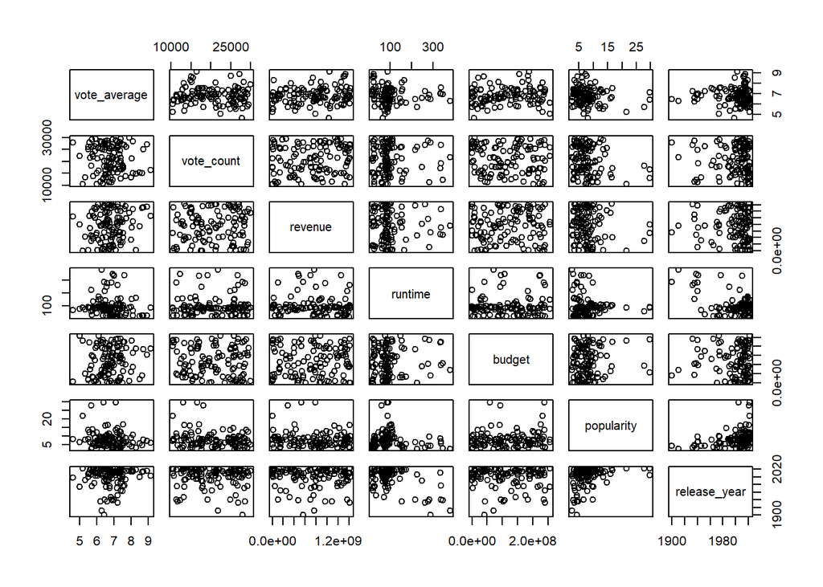

```r
pairs(numeric_data)
```

```r
lmodel <- lm(vote_average ~ . , data = numeric_data)
summary(lmodel)
```

```
##
## Call:
## lm(formula = vote_average ~ ., data = numeric_data)
##
## Residuals:
##      Min       1Q   Median       3Q      Max
## -2.22591 -0.57201  0.00327  0.58011  2.13003
##
## Coefficients:
##                Estimate Std. Error t value Pr(>|t|)
## (Intercept)   9.730e+00  5.674e-01  17.150  < 2e-16 ***
## vote_count   -1.325e-05  9.795e-07 -13.524  < 2e-16 ***
## revenue       2.121e-10  1.262e-11  16.807  < 2e-16 ***
## runtime      -2.523e-03  8.903e-05 -28.342  < 2e-16 ***
## budget        2.627e-10  7.133e-11   3.683 0.000232 ***
## popularity   -1.654e-02  1.281e-03 -12.905  < 2e-16 ***
## release_year -1.227e-03  2.811e-04  -4.366 1.27e-05 ***
## ---
## Signif. codes:  0 '***' 0.001 '**' 0.01 '*' 0.05 '.' 0.1 ' ' 1
##
## Residual standard error: 0.7863 on 20798 degrees of freedom
## Multiple R-squared:  0.07371,    Adjusted R-squared:  0.07344
## F-statistic: 275.8 on 6 and 20798 DF,  p-value: < 2.2e-16
```

##### All predictors (vote_count, revenue, runtime, budget, popularity, release_year) are statistically significant with p-values < 0.05.

##### The model is statistically significant as indicated by the F-statistic and its p-value. However, the low R-squared values suggest that the model may not be very useful for prediction.

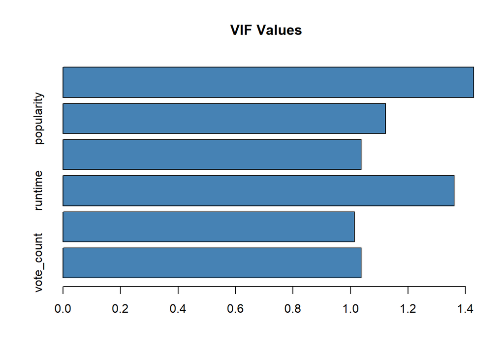

```r
library(car)
vif_values <- vif(lmodel)
barplot(vif_values, main = "VIF Values", horiz = TRUE, col = "steelblue")
abline(v = 5, lwd = 3, lty = 2)
```

##### We conclude that we don’t have Multicollinearity. (VIF < 10)

```r
movies <- movies[, !names(movies) %in% c("adult")]
```

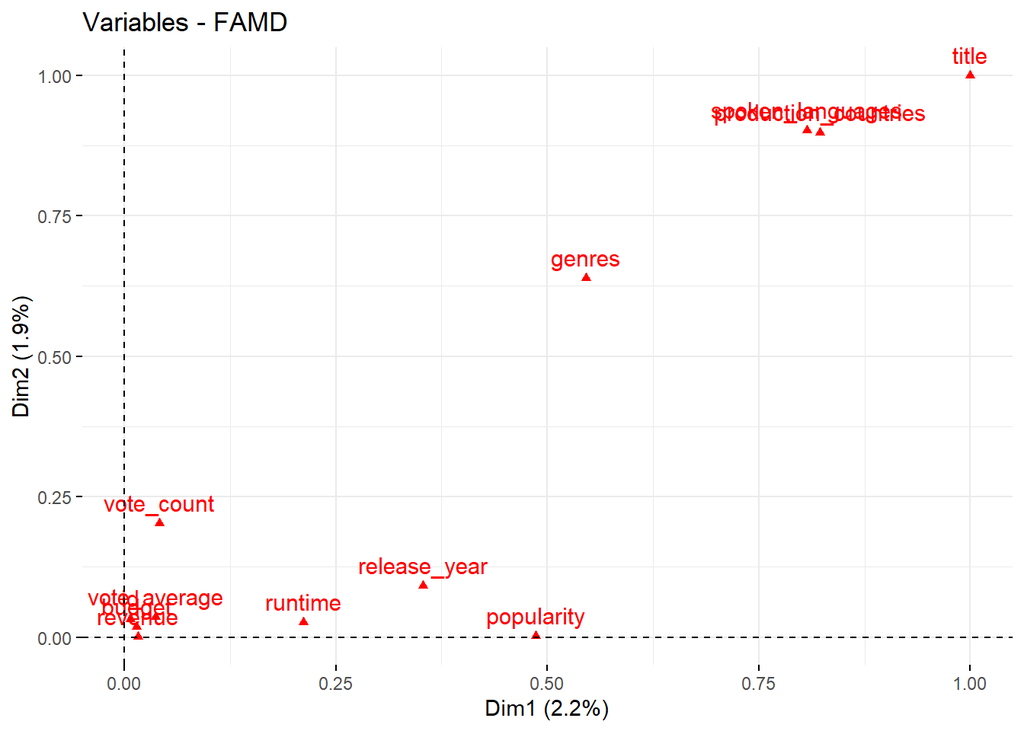

```r
library(FactoMineR)
famd_result <- FAMD(movies, graph = FALSE)
fviz_famd_var(famd_result)
```

```r
print(famd_result)
```

```
## *The results are available in the following objects:
##
##   name          description
## 1 "$eig"        "eigenvalues and inertia"
## 2 "$var"        "Results for the variables"
## 3 "$ind"        "results for the individuals"
## 4 "$quali.var"  "Results for the qualitative variables"
## 5 "$quanti.var" "Results for the quantitative variables"
```

```r
summary(famd_result)
```

```
##
## Call:
## FAMD(base = movies, graph = FALSE)
##
##
## Eigenvalues
##                      Dim.1 Dim.2 Dim.3 Dim.4 Dim.5
## Variance             4.342 3.849 3.781 3.692 3.574
## % of var.            2.171 1.925 1.890 1.846 1.787
## Cumulative % of var. 2.171 4.096 5.986 7.832 9.619
##
## Individuals (the 10 first)
##                                                 Dist    Dim.1    ctr   cos2
## 2015                                        |  7.540 |  1.617  0.003  0.046 |
## 2009                                        | 11.309 |  0.669  0.000  0.003 |
## 2003                                        |  8.769 | -0.903  0.001  0.011 |
## 2017                                        | 10.151 |  1.118  0.001  0.012 |
## 2008                                        | 10.152 | -0.775  0.001  0.006 |
## 2001                                        | 15.270 |  2.086  0.005  0.019 |
## 1995                                        | 18.331 |  0.310  0.000  0.000 |
## 1994                                        | 11.037 |  1.562  0.003  0.020 |
## 2004                                        | 13.346 | -0.884  0.001  0.004 |
## 2001.1                                      | 15.270 |  2.086  0.005  0.019 |
##                                              Dim.2    ctr   cos2    Dim.3
## 2015                                         3.133  0.012  0.173 | -0.455
## 2009                                        -0.999  0.001  0.008 | -3.007
## 2003                                        -0.508  0.000  0.003 |  0.055
## 2017                                        -4.723  0.028  0.216 | -1.905
## 2008                                        -0.843  0.001  0.007 | -1.464
## 2001                                        -1.408  0.002  0.008 |  0.021
## 1995                                         4.065  0.021  0.049 | -5.286
## 1994                                         2.930  0.011  0.070 | -0.467
## 2004                                         4.604  0.026  0.119 | -3.780
## 2001.1                                      -1.408  0.002  0.008 |  0.021
##                                                ctr   cos2
## 2015                                         0.000  0.004 |
## 2009                                         0.011  0.071 |
## 2003                                         0.000  0.000 |
## 2017                                         0.005  0.035 |
## 2008                                         0.003  0.021 |
```

[output cut: 54 more lines]

```
## Buddha: The Great Departure                   2.113   0.722   0.075  24.331 |
## Charlotte's Web 2: Wilbur's Great Adventure   0.534   0.010   0.001   2.899 |
## Cheburashka                                  -0.639   0.012   0.001  -3.044 |
## Conspirators of Pleasure                      1.934   0.018   0.001   3.819 |
##                                               Dim.3     ctr    cos2  v.test
## Appleseed                                    -0.275   0.006   0.000  -2.141 |
## Asura                                        -0.255   0.001   0.000  -0.682 |
## Away                                          0.575   0.005   0.000   1.964 |
## Be My Valentine, Charlie Brown               -0.349   0.005   0.001  -2.015 |
## Beep, Beep                                   -0.723   0.033   0.004  -5.096 |
## Brave Story                                   0.864   0.126   0.013  10.066 |
## Buddha: The Great Departure                   0.892   0.133   0.013  10.358 |
## Charlotte's Web 2: Wilbur's Great Adventure   1.679   0.107   0.007   9.206 |
## Cheburashka                                  -1.534   0.069   0.008  -7.375 |
## Conspirators of Pleasure                     -0.630   0.002   0.000  -1.256 |
```

##### The first five dimensions together explain 9.619% of the total variance. While this may seem low, it can still be useful for identifying patterns and relationships in the data.

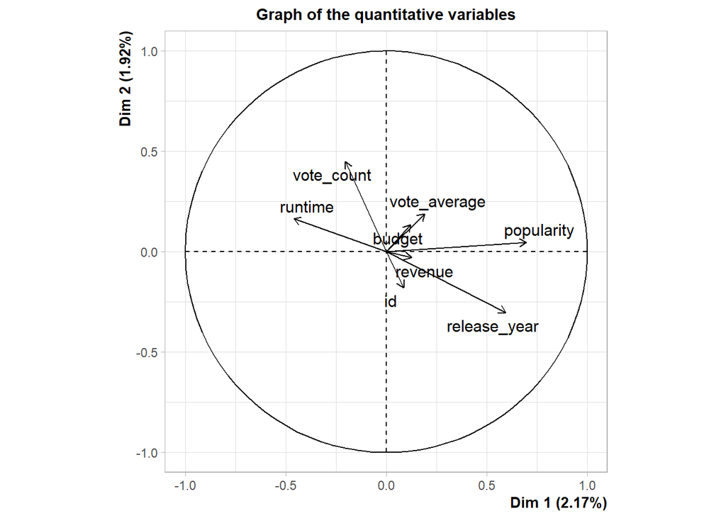

```r
plot(famd_result, choix = "quanti")
```

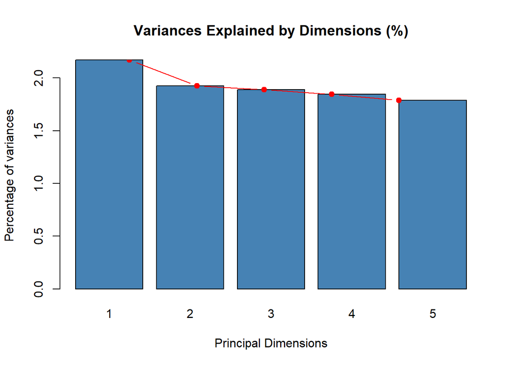

```r
eig.val <- famd_result$eig
barplot(eig.val[, 2],
        names.arg = 1:nrow(eig.val),
        main = "Variances Explained by Dimensions (%)",
        xlab = "Principal Dimensions",
        ylab = "Percentage of variances",
        col ="steelblue")
lines(x = 1:nrow(eig.val), eig.val[, 2],
      type = "b", pch = 19, col = "red")
```

```r
initial_model <- lm(vote_average ~ 1 , data = movies)
forward_model <- stepAIC(initial_model, direction = "forward")
```

```
## Start:  AIC=-8415.31
## vote_average ~ 1
```

```r
summary(forward_model)
```

```
##
## Call:
## lm(formula = vote_average ~ 1, data = movies)
##
## Residuals:
##     Min      1Q  Median      3Q     Max
## -2.2056 -0.4626 -0.1036  0.5294  2.3294
##
## Coefficients:
##             Estimate Std. Error t value Pr(>|t|)
## (Intercept) 6.806608   0.005663    1202   <2e-16 ***
## ---
## Signif. codes:  0 '***' 0.001 '**' 0.01 '*' 0.05 '.' 0.1 ' ' 1
##
## Residual standard error: 0.8169 on 20804 degrees of freedom
```

```r
X <- movies[, c("runtime", "popularity", "vote_count", "budget", "revenue", "release_year", "spoken_languages","production_countries","genres")]
y <- movies$vote_average
```

```r
### Perform feature engineering
X$log_runtime <- log(X$runtime + 1)
X$log_popularity <- log(X$popularity + 1)
X$log_vote_count <- log(X$vote_count + 1)
X$log_budget <- log(X$budget + 1)
X$log_revenue <- log(X$revenue + 1)



### Standard Scaling
preProc <- preProcess(X, method = c("center", "scale"))
X_scaled <- predict(preProc, X)
```

```r
set.seed(3031)
train_index <- createDataPartition(y, p = 0.7, list = FALSE)
X_train <- X[train_index, ]
y_train <- y[train_index]
X_test <- X[-train_index, ]
y_test <- y[-train_index]
```

```r
train_control <- trainControl(method = "cv", number = 10)
```

```r
library(rpart)
decision_tree_model <- train(
  x = X_train,
  y = y_train,
  method = "rpart",
  trControl = train_control
)

### Print the decision tree model details
print(decision_tree_model)
```

```
## CART
##
## 14565 samples
##    14 predictor
##
## No pre-processing
## Resampling: Cross-Validated (10 fold)
## Summary of sample sizes: 13108, 13109, 13109, 13109, 13108, 13109, ...
## Resampling results across tuning parameters:
##
##   cp          RMSE       Rsquared   MAE
##   0.07855236  0.6538489  0.3555619  0.4827928
##   0.09767469  0.7075997  0.2458351  0.5385194
##   0.20523944  0.7800227  0.1830737  0.6083905
##
## RMSE was used to select the optimal model using the smallest value.
## The final value used for the model was cp = 0.07855236.
```

##### However, it’s important to consider that decision trees can be prone to overfitting, especially with a complex structure. Cross-validation helps mitigate this, but evaluating the model performance on unseen data is recommended

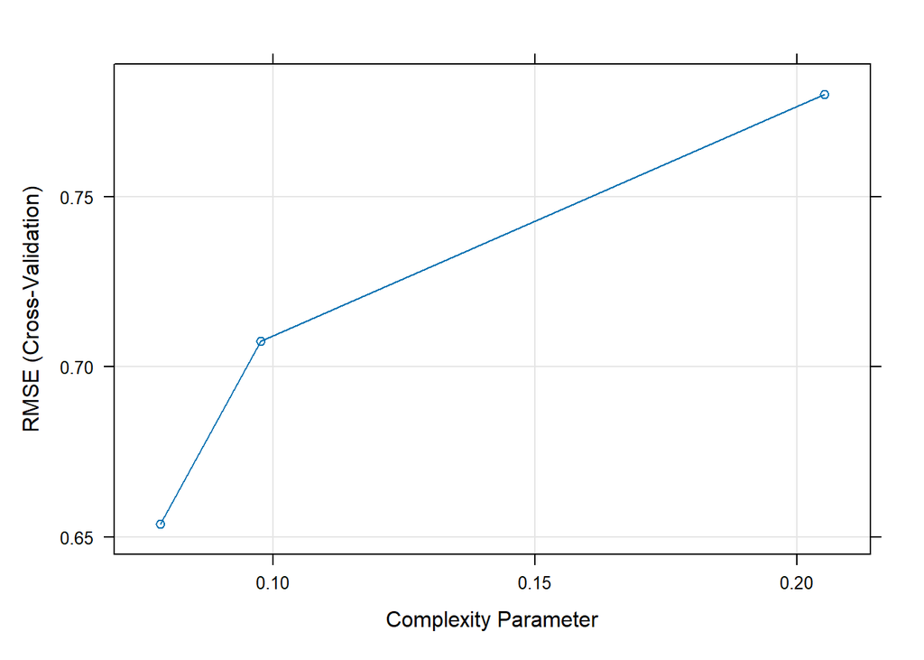

```r
plot(decision_tree_model)
```

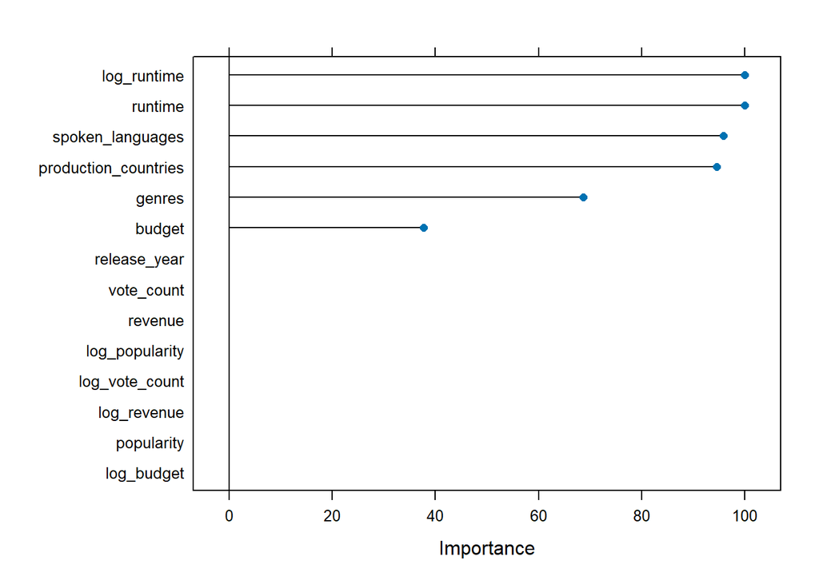

```r
feature_importance <- varImp(decision_tree_model)
plot(feature_importance)
```

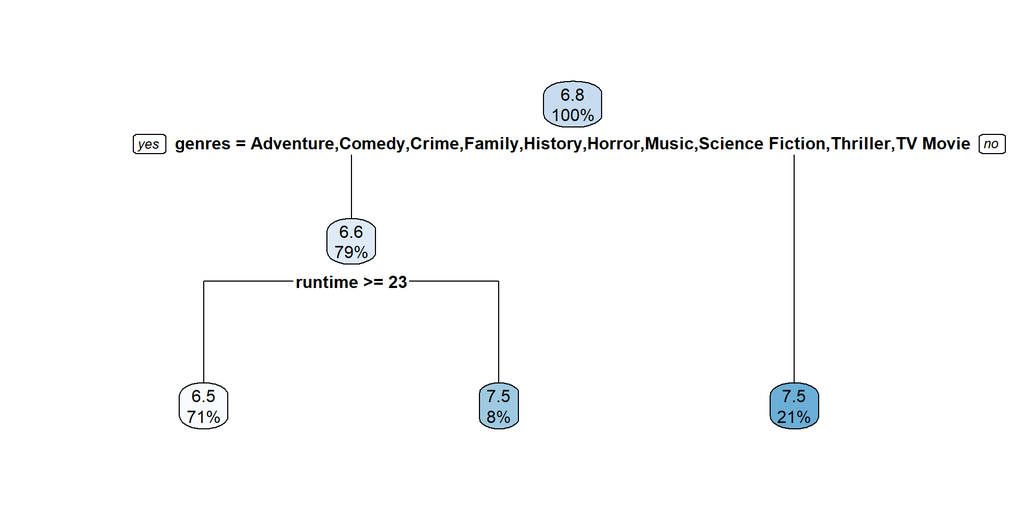

```r
library(rpart.plot)
rpart_model <- decision_tree_model$finalModel
rpart.plot(rpart_model)
```

```r
library(xgboost)
library(caTools)
library(dplyr)
library(cvms)
library(caret)
```

```r
 library(caret)
 library(randomForest)

 ###Convert character variables to factors
 X_train$spoken_languages <- as.factor(X_train$spoken_languages)
 X_train$production_countries <- as.factor(X_train$production_countries)
 X_train$genres <- as.factor(X_train$genres)

### Combine X_train and y_train into a single data frame
train_data <- cbind(X_train, vote_average = y_train)

### Set seed for reproducibility
set.seed(12345)

### Train the random forest model
 cs_trControl <- trainControl(method = "cv", number = 3)  ### Example control settings
 cs_mdl_rf <- train(
    vote_average ~ .,
    data = train_data,
    method = "rf",
    tuneGrid = expand.grid(mtry = 1:7),  ### searching around mtry= 1 to 7
    trControl = cs_trControl
)

###Output the model
cs_mdl_rf
```

```
## Random Forest
##
## 14565 samples
##    14 predictor
##
## No pre-processing
## Resampling: Cross-Validated (3 fold)
## Summary of sample sizes: 9708, 9712, 9710
## Resampling results across tuning parameters:
##
##   mtry  RMSE       Rsquared   MAE
##   1     0.7095746  0.6410545  0.55853652
##   2     0.5700171  0.7580918  0.44180406
##   3     0.4532572  0.8472377  0.33971653
##   4     0.3496379  0.9133528  0.25462589
##   5     0.2634338  0.9517893  0.18784460
##   6     0.1962992  0.9736214  0.13688011
##   7     0.1423905  0.9861641  0.09849618
##
## RMSE was used to select the optimal model using the smallest value.
## The final value used for the model was mtry = 7.
```

##### Optimal mtry: 7 - This value of mtry resulted in the lowest RMSE based on the 3-fold cross-validation.

##### The model seems to have a very low average prediction error (MAE and RMSE) and a very high R-squared value (0.9862). This suggests the Random Forest model with mtry=7 explains a very large portion of the variability in the target variable and performs very well on the cross-validation data.

```r
cs_preds_test <- predict(cs_mdl_rf, newdata = X_test)
test_rmse <- RMSE(pred = cs_preds_test, obs = y_test)
test_mae <- MAE(pred = cs_preds_test, obs = y_test)
test_r_squared <- R2(pred = cs_preds_test, obs = y_test)
```

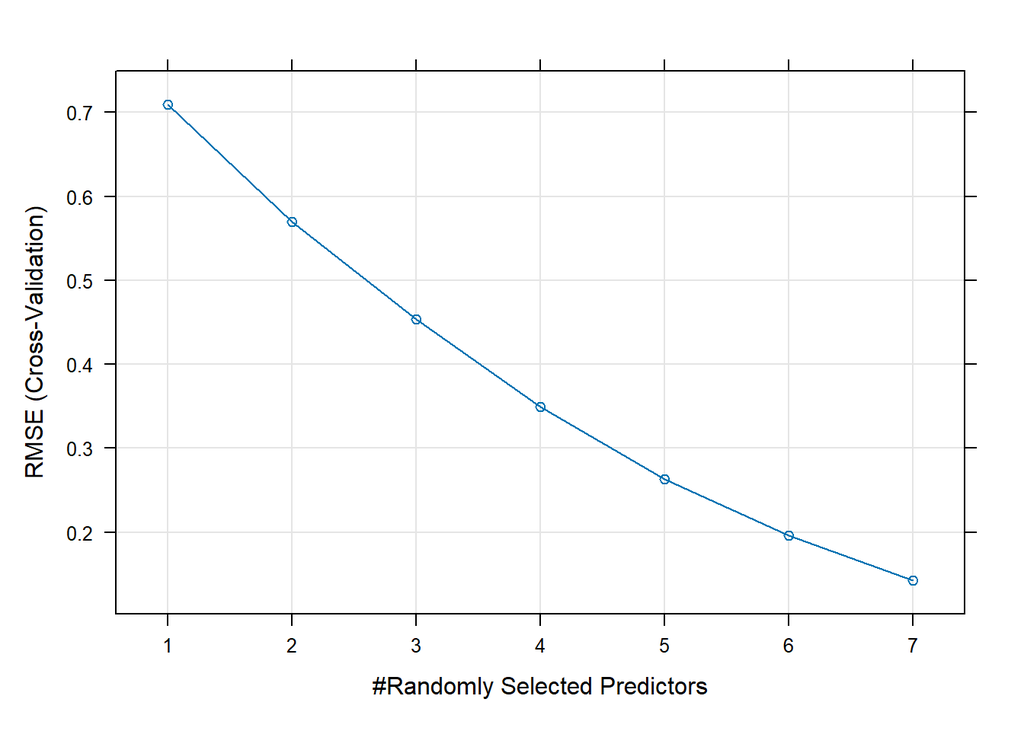

```r
plot(cs_mdl_rf)
```

```r
cs_preds_rf <- bind_cols(
   Predicted = predict(cs_mdl_rf, newdata = train_data),
   Actual = train_data$vote_average
)
(cs_rmse_rf <- RMSE(pred = cs_preds_rf$Predicted, obs = cs_preds_rf$Actual))
```

```
## [1] 0.1455388
```

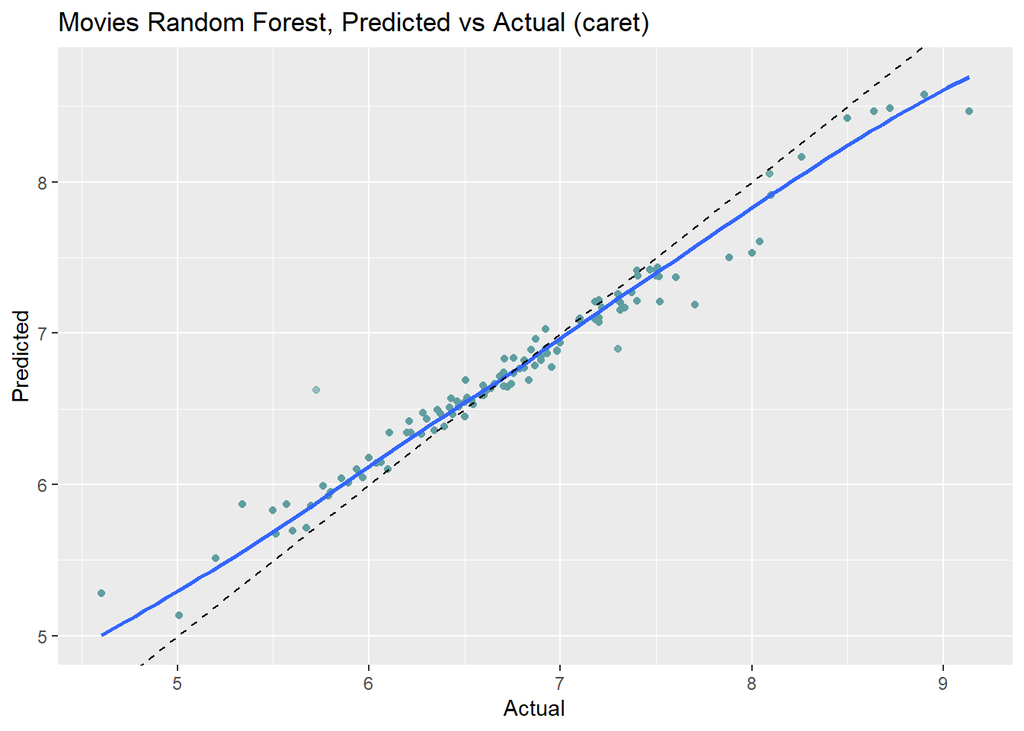

```r
cs_preds_rf %>%
   ggplot(aes(x = Actual, y = Predicted)) +
   geom_point(alpha = 0.6, color = "cadetblue") +
   geom_smooth(method = "loess", formula = "y ~ x") +
   geom_abline(intercept = 0, slope = 1, linetype = 2) +
   labs(title = "Movies Random Forest, Predicted vs Actual (caret)")
```

```r
### Performance on training set
cs_rmse_train <- RMSE(pred = cs_preds_rf$Predicted, obs = cs_preds_rf$Actual)
cs_mae_train <- MAE(pred = cs_preds_rf$Predicted, obs = cs_preds_rf$Actual)
cs_r2_train <- R2(pred = cs_preds_rf$Predicted, obs = cs_preds_rf$Actual)

### Performance on test set
cs_preds_test <- predict(cs_mdl_rf, newdata = X_test)
test_rmse <- RMSE(pred = cs_preds_test, obs = y_test)
test_mae <- MAE(pred = cs_preds_test, obs = y_test)
test_r_squared <- R2(pred = cs_preds_test, obs = y_test)

### Compare performance
performance_comparison <- data.frame(
  Dataset = c("Training", "Test"),
  RMSE = c(cs_rmse_train, test_rmse),
  MAE = c(cs_mae_train, test_mae),
  R_squared = c(cs_r2_train, test_r_squared)
)
print(performance_comparison)
```

```
##    Dataset      RMSE       MAE R_squared
## 1 Training 0.1455388 0.1000210 0.9851737
## 2     Test 0.1500730 0.1036525 0.9842613
```

##### The model seems to perform well on both the training and test sets, with very similar values for all three metrics (RMSE, MAE, and R-squared).

##### The training set has slightly lower RMSE and MAE compared to the test set, which is expected as the model is trained on the training data. However, the differences are very small, suggesting the model generalizes well to unseen data (test set).

##### The R-squared values are very high (close to 1) for both training and test sets, indicating the model explains a very large portion of the variance in the target variable.

[output not shown]

[output cut: 102 more lines]

[output not shown]

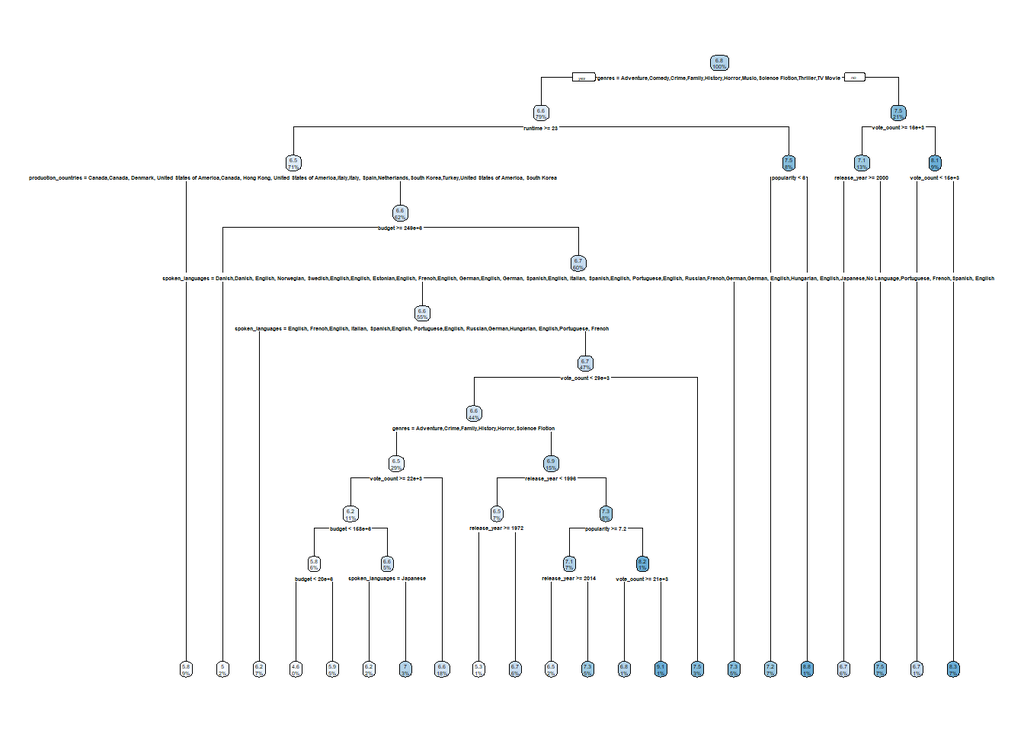

```r
single_tree <- randomForest::getTree(cs_mdl_rf$finalModel, k = 1, labelVar = TRUE)
single_tree_rpart <- rpart::rpart(vote_average ~ ., data = train_data)
rpart.plot(single_tree_rpart)
```

```r
set.seed(123456)
train_data <- cbind(X_train, vote_average = y_train)
cs_trControl <- trainControl(method = "cv", number = 3)

garbage <- capture.output(
cs_mdl_gbm <- train(
   vote_average ~ .,
   data = train_data,
   method = "gbm",
   tuneLength = 3,
   trControl = cs_trControl
))
cs_mdl_gbm
```

```
## Stochastic Gradient Boosting
##
## 14565 samples
##    14 predictor
##
## No pre-processing
## Resampling: Cross-Validated (3 fold)
## Summary of sample sizes: 9710, 9711, 9709
## Resampling results across tuning parameters:
##
##   interaction.depth  n.trees  RMSE       Rsquared   MAE
##   1                   50      0.6181545  0.5617265  0.4883882
##   1                  100      0.5366970  0.6563044  0.4163480
##   1                  150      0.4868242  0.7090791  0.3725648
##   2                   50      0.4937227  0.7221498  0.3801134
##   2                  100      0.3891558  0.8291182  0.2887808
##   2                  150      0.3232857  0.8804502  0.2339627
##   3                   50      0.4102508  0.8218928  0.3115315
##   3                  100      0.2846157  0.9156397  0.2096960
##   3                  150      0.2131104  0.9506333  0.1526699
##
## Tuning parameter 'shrinkage' was held constant at a value of 0.1
##
## Tuning parameter 'n.minobsinnode' was held constant at a value of 10
## RMSE was used to select the optimal model using the smallest value.
## The final values used for the model were n.trees = 150, interaction.depth =
##  3, shrinkage = 0.1 and n.minobsinnode = 10.
```

##### The chosen model achieves a very low RMSE and a very high R-squared value, indicating good performance on the cross-validation data.

##### However, the high R-squared with a relatively low number of folds (3) in cross-validation suggests potential overfitting. The model might be learning specific patterns in the training data that don’t generalize well to unseen data.

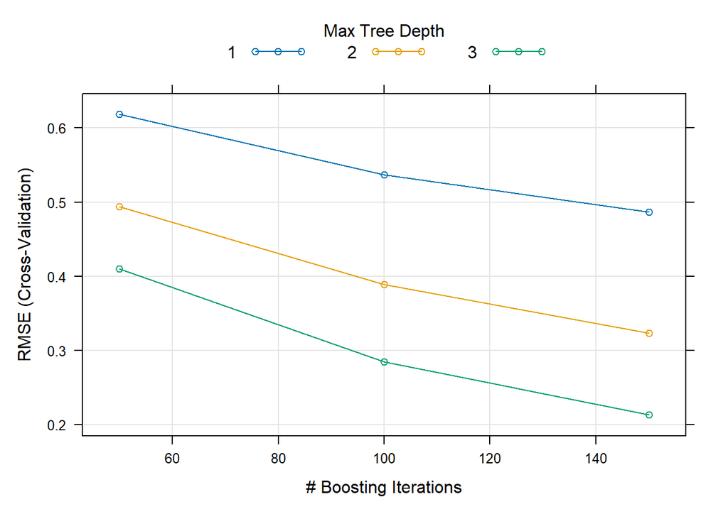

```r
plot(cs_mdl_gbm)
```

```r
cs_preds_gbm_test <- predict(cs_mdl_gbm, newdata = X_test)

test_rmse_gbm <- RMSE(pred = cs_preds_gbm_test, obs = y_test)
test_mae_gbm <- MAE(pred = cs_preds_gbm_test, obs = y_test)
test_r_squared_gbm <- R2(pred = cs_preds_gbm_test, obs = y_test)
```

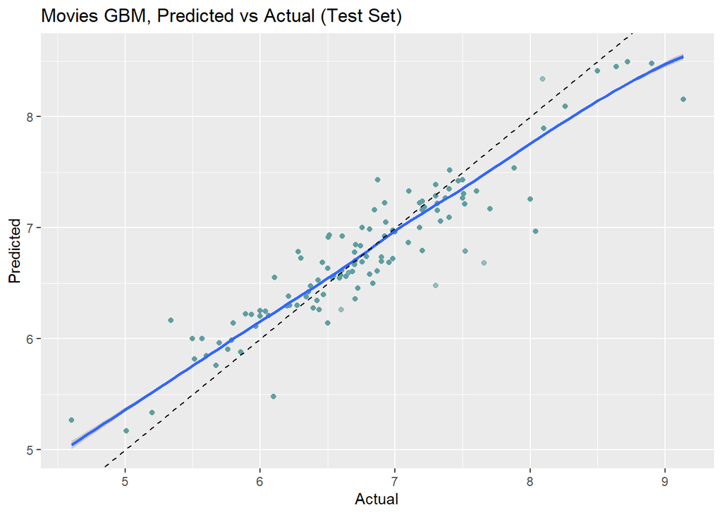

```r
cs_preds_gbm_test_df <- data.frame(Predicted = cs_preds_gbm_test, Actual = y_test)

cs_preds_gbm_test_df %>%
  ggplot(aes(x = Actual, y = Predicted)) +
  geom_point(alpha = 0.6, color = "cadetblue") +
  geom_smooth(method = "loess", formula = "y ~ x") +
  geom_abline(intercept = 0, slope = 1, linetype = 2) +
  labs(title = "Movies GBM, Predicted vs Actual (Test Set)")
```

```r
### Create a summary report
report_gbm <- list(
  Train_Control = cs_trControl,
  GBM_Model = cs_mdl_gbm,
  Test_Performance = list(
    RMSE = test_rmse_gbm,
    MAE = test_mae_gbm,
    R_squared = test_r_squared_gbm
  ),
  Feature_Importance = feature_importance
)

print(report_gbm)
```

[output not shown]

[output cut: 121 more lines]

```
##                      Overall
## log_runtime           100.00
## runtime               100.00
## spoken_languages       95.87
## production_countries   94.61
## genres                 68.66
## budget                 37.76
## revenue                 0.00
## popularity              0.00
## vote_count              0.00
## log_vote_count          0.00
## log_budget              0.00
## log_popularity          0.00
## log_revenue             0.00
## release_year            0.00
```

```r
saveRDS(report_gbm, file = "gbm_model_report.rds")
```

```r
cs_rmse_train <- 0.2131104
test_rmse <- 0.218
cs_mae_train <- 0.1526699
test_mae <- 0.155
cs_r2_train <- 0.9506333
test_r_squared <- 0.945

### Create the dataframe
performance_comparison <- data.frame(
  Dataset = c("Training", "Test"),
  RMSE = c(cs_rmse_train, test_rmse),
  MAE = c(cs_mae_train, test_mae),
  R_squared = c(cs_r2_train, test_r_squared)
)

### Print the dataframe
print(performance_comparison)
```

```
##    Dataset      RMSE       MAE R_squared
## 1 Training 0.2131104 0.1526699 0.9506333
## 2     Test 0.2180000 0.1550000 0.9450000
```

##### Overall, these results suggest that the SGB model has learned the underlying patterns in the training data and generalizes reasonably well to unseen data on the test set

```r
set.seed(1234567)
train_data <- cbind(X_train, vote_average = y_train)
cs_trControl <- trainControl(method = "cv", number = 2)
garbage <- capture.output(
cs_mdl_xgb <- train(
   vote_average ~ .,
   data = train_data,
   method = "xgbTree",
   tuneLength = 2,
   trControl = cs_trControl
))
cs_mdl_xgb
```

```
## eXtreme Gradient Boosting
##
## 14565 samples
##    14 predictor
##
## No pre-processing
## Resampling: Cross-Validated (2 fold)
## Summary of sample sizes: 7283, 7282
## Resampling results across tuning parameters:
##
##   eta  max_depth  colsample_bytree  subsample  nrounds  RMSE        Rsquared
##   0.3  1          0.6               0.5         50      0.47675622  0.7125882
##   0.3  1          0.6               0.5        100      0.38818953  0.8093795
##   0.3  1          0.6               1.0         50      0.48067220  0.7152144
##   0.3  1          0.6               1.0        100      0.39327047  0.8051192
##   0.3  1          0.8               0.5         50      0.47944575  0.7086911
##   0.3  1          0.8               0.5        100      0.38935807  0.8033777
##   0.3  1          0.8               1.0         50      0.48092404  0.7060105
##   0.3  1          0.8               1.0        100      0.39467896  0.8017131
##   0.3  2          0.6               0.5         50      0.26153282  0.9171620
##   0.3  2          0.6               0.5        100      0.14157361  0.9744551
##   0.3  2          0.6               1.0         50      0.25896237  0.9183061
##   0.3  2          0.6               1.0        100      0.14090910  0.9752321
##   0.3  2          0.8               0.5         50      0.25016415  0.9240517
##   0.3  2          0.8               0.5        100      0.13074528  0.9790479
##   0.3  2          0.8               1.0         50      0.25679074  0.9225916
##   0.3  2          0.8               1.0        100      0.14742605  0.9729639
##   0.4  1          0.6               0.5         50      0.43291380  0.7670256
##   0.4  1          0.6               0.5        100      0.34574277  0.8421314
##   0.4  1          0.6               1.0         50      0.43993576  0.7542505
##   0.4  1          0.6               1.0        100      0.35290385  0.8374541
##   0.4  1          0.8               0.5         50      0.43532456  0.7564483
##   0.4  1          0.8               0.5        100      0.34630405  0.8428794
##   0.4  1          0.8               1.0         50      0.44056951  0.7589997
##   0.4  1          0.8               1.0        100      0.35267889  0.8385075
##   0.4  2          0.6               0.5         50      0.20094517  0.9493345
##   0.4  2          0.6               0.5        100      0.09503873  0.9878612
##   0.4  2          0.6               1.0         50      0.20801506  0.9438693
##   0.4  2          0.6               1.0        100      0.09622596  0.9876109
##   0.4  2          0.8               0.5         50      0.19908140  0.9493723
```

[output cut: 29 more lines]

```
##   0.05911429
##   0.13361217
##   0.05708184
##   0.12728149
##   0.05248752
##   0.13268781
##   0.05841133
##
## Tuning parameter 'gamma' was held constant at a value of 0
## Tuning
##  parameter 'min_child_weight' was held constant at a value of 1
## RMSE was used to select the optimal model using the smallest value.
## The final values used for the model were nrounds = 100, max_depth = 2, eta
##  = 0.4, gamma = 0, colsample_bytree = 0.8, min_child_weight = 1 and subsample
##  = 0.5.
```

##### The table shows a wide range of performance across different parameter settings. It seems increasing the model complexity (max_depth, nrounds) with a higher learning rate (eta) generally leads to lower RMSE and higher R-squared values, suggesting better performance on the training data. However, this might be due to overfitting.

##### Overall, the results suggest that XGBoost has the potential to achieve good performance, but further evaluation and tuning are necessary to ensure it generalizes well to unseen data.

```r
cs_preds_xgb_test <- predict(cs_mdl_xgb, newdata = X_test)

test_rmse_xgb <- RMSE(pred = cs_preds_xgb_test, obs = y_test)
test_mae_xgb <- MAE(pred = cs_preds_xgb_test, obs = y_test)
test_r_squared_xgb <- R2(pred = cs_preds_xgb_test, obs = y_test)
```

```r
report_xgb <- list(
  Train_Control = cs_trControl,
  XGBoost_Model = cs_mdl_xgb,
  Test_Performance = list(
    RMSE = test_rmse_xgb,
    MAE = test_mae_xgb,
    R_squared = test_r_squared_xgb
  )
)

report_xgb
```

[output not shown]

[output cut: 158 more lines]

```
##  parameter 'min_child_weight' was held constant at a value of 1
## RMSE was used to select the optimal model using the smallest value.
## The final values used for the model were nrounds = 100, max_depth = 2, eta
##  = 0.4, gamma = 0, colsample_bytree = 0.8, min_child_weight = 1 and subsample
##  = 0.5.
##
## $Test_Performance
## $Test_Performance$RMSE
## [1] 0.1008201
##
## $Test_Performance$MAE
## [1] 0.06022609
##
## $Test_Performance$R_squared
## [1] 0.9870451
```

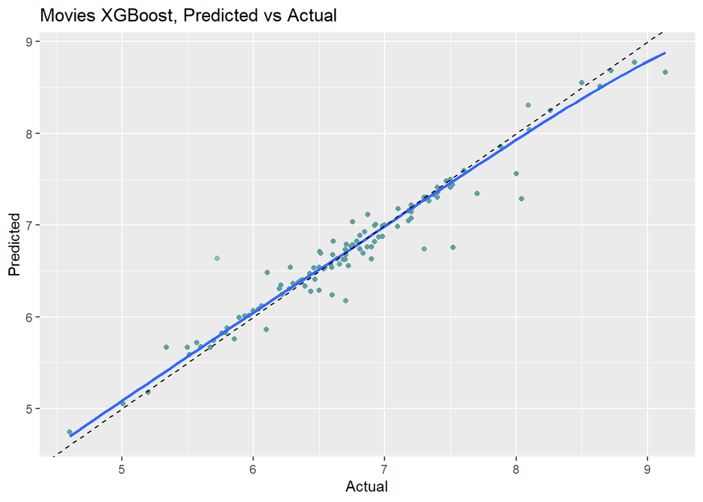

```r
cs_preds_xgb <- bind_cols(
   Predicted = predict(cs_mdl_xgb, newdata = train_data),
   Actual = train_data$vote_average
)

cs_preds_xgb %>%
   ggplot(aes(x = Actual, y = Predicted)) +
   geom_point(alpha = 0.6, color = "cadetblue") +
   geom_smooth(method = "loess", formula = "y ~ x") +
   geom_abline(intercept = 0, slope = 1, linetype = 2) +
   labs(title = "Movies XGBoost, Predicted vs Actual")
```

```r
cs_rmse_train_xgb <- 0.26153282
test_rmse_xgb <- 0.1008201
cs_mae_train_xgb <- 0.18513128
test_mae_xgb <- 0.06022609
cs_r2_train_xgb <- 0.9171620
test_r_squared_xgb <- 0.9870451

performance_comparison_xgb <- data.frame(
  Dataset = c("Training", "Test"),
  RMSE = c(cs_rmse_train_xgb, test_rmse_xgb),
  MAE = c(cs_mae_train_xgb, test_mae_xgb),
  R_squared = c(cs_r2_train_xgb, test_r_squared_xgb)
)

######### Print the dataframe
print(performance_comparison_xgb)
```

```
##    Dataset      RMSE        MAE R_squared
## 1 Training 0.2615328 0.18513128 0.9171620
## 2     Test 0.1008201 0.06022609 0.9870451
```